# Non-parametric tests

## Real-world data problems

So far, we have learned about and used statistical modeling and analysis techniques that rely on a mostly-shared set of assumptions. Normality of data distribution and equality of variance are common assumptions. These are called “parametric” methods. Unfortunately, data collection in environmental sciences rarely results in “pretty” data that meets all the assumptions of parametric methods. We commonly collect data that have some sort of non-normal skew, or unequal variance.

Luckily, statistical methods that relax assumptions of normality and equality of variance have been developed. These are called non-parametric methods, and you’ll likely have to use them in your own research projects. In this lesson, we’ll learn about non-parametric equivalents of Pearson’s correlation, Student’s t-test, and one-way ANOVA.

We’ll go back to using the `flights` dataset from the `nycflights13` package. Let’s load it and do some cursory data cleaning now. We’ll also filter to just July because otherwise there are too many data points for simple exercises.

```r
# Adapt flight dataset
flights2 <- flights %>%
  # Save only variables that we want to use
  select(carrier, origin, dest, dep_delay, arr_delay,
         air_time, distance, month) %>%
  # Remove cancelled flights
  na.omit() %>%
  # Filter to summer months
  filter(month ==7) %>%
  # Change data type for carrier, origin, destination to factor
  mutate_if(is.character, as.factor)

# Determine which airports have fewer than 50 arrivals from NYC
uncommon_airports <- flights2 %>%
  # Group by destination
  group_by(dest) %>%
  # Summarise results: count number of arrivals to each destination
  summarise(count = n()) %>%
  # Filter out airports with fewer than 50 arrivals from NYC
  filter(count < 50) %>%
  # Remove count column
  mutate(count = NULL) %>%
  # Convert to a vector
  pull(dest) %>%
  # Remove levels that now have 0 samples
  droplevels()

# Determine which carriers have fewer than 50 departures from NYC
uncommon_carriers <- flights2 %>%
  # Group by carrier
  group_by(carrier) %>%
  # Summarize results: count number of times each carrier left NYC
  summarise(count = n()) %>%
  # Filter out carriers with fewer than 50 total departures from NYC
  filter(count < 50) %>%
  # Remove count column
  mutate(count = NULL) %>%
  # Convert to a vector
  pull(carrier) %>%
  # Remove levels that now have 0 samples
  droplevels()

# Build negate function
'%notin%' <- function(x,y)!('%in%'(x,y))
# I like this function and use it a lot. It's not included in Base R.
# This is the inverse of "must include," so you can think of it as "must not include"

# Remove uncommon airports from dataset
flights2 <- flights2 %>%
  filter(dest %notin% uncommon_airports)

# Remove uncommon carriers from dataset
flights2 <- flights2 %>%
  filter(carrier %notin% uncommon_carriers)

# Drop levels with 0 samples
flights2 <- droplevels(flights2)

# View results
summary(flights2)
```

```
    carrier     origin          dest         dep_delay         arr_delay
 UA     :4951   EWR:9875   LAX    : 1494   Min.   : -22.00   Min.   :-66.00
 B6     :4718   JFK:9511   ORD    : 1487   1st Qu.:  -4.00   1st Qu.:-16.00
 DL     :4183   LGA:8308   ATL    : 1448   Median :   0.00   Median : -2.00
 EV     :4004              BOS    : 1312   Mean   :  21.39   Mean   : 16.54
 AA     :2738              MCO    : 1236   3rd Qu.:  23.00   3rd Qu.: 26.00
 MQ     :2098              CLT    : 1206   Max.   :1005.00   Max.   :989.00
 (Other):5002              (Other):19511
    air_time        distance        month
 Min.   : 23.0   Min.   :  94   Min.   :7
 1st Qu.: 79.0   1st Qu.: 509   1st Qu.:7
 Median :124.0   Median : 937   Median :7
 Mean   :145.6   Mean   :1061   Mean   :7
 3rd Qu.:188.0   3rd Qu.:1400   3rd Qu.:7
 Max.   :629.0   Max.   :4963   Max.   :7
```

I know from doing my own data explorations that these data have issues with meeting parametric assumptions of normality and equality of variance. We will now go through some exercises to learn how we can avoid these issues with nonparametric models.

## Non-parametric version of Pearson’s correlation: Spearman rank correlation

Let’s say we wanted to test the correlation between departure delay and arrival delay. Pearson’s correlation assumes normal distributions of these two quantitaive variables. Let’s check that.

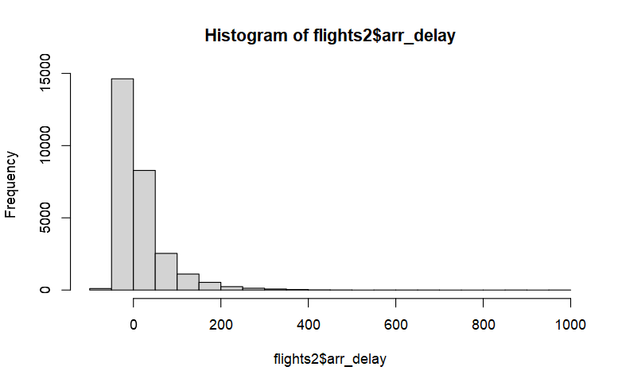

```r
hist(flights2$arr_delay)
```

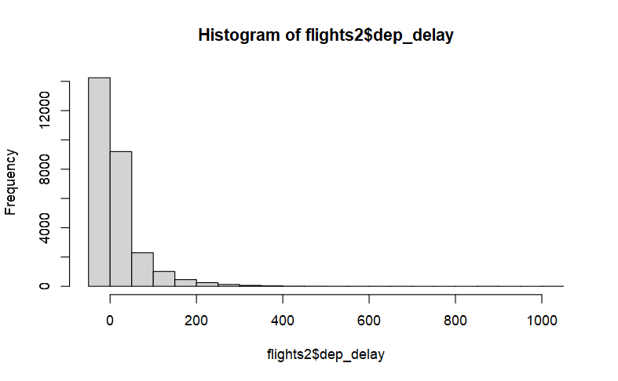

```r
hist(flights2$dep_delay)
```

These are definitely not normal distributions. Notice how most of the data is contained on the left side of the plot, but there’s a super long right-hand tail. Most flights arrive and depart on time, but a few flights have crazy long delays. This would be challenging to assess with Pearson’s correlation, as the violation of the assumptions may give us misleading results. Let’s use Spearman’s rank correlation instead, which does not assume normality. Spearman rank correlation assesses the monotonic relationship between variables, rather than assessing linear relationships directly. This is cool because it also allows for the assessment of the strength of non-linear relationships– Spearman’s rank correlation just tells you the strength of increasing or decreasing trends between the two variables.

```r
# Run spearman correlation
flights2 %>%
  dplyr::select(dep_delay, arr_delay) %>%
  cor(method='spearman')
```

```
          dep_delay arr_delay
dep_delay 1.0000000 0.7012285
arr_delay 0.7012285 1.0000000
```

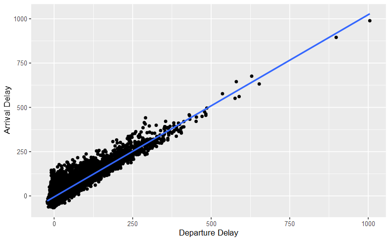

```r
# Plot data
ggplot(data=flights2) +
  geom_point(aes(x=dep_delay, y=arr_delay)) +
  geom_smooth(aes(x=dep_delay, y=arr_delay), method='lm',
              se=FALSE) +
  labs(x='Departure Delay', y='Arrival Delay')
```

There is a strong positive relationship between departure delay time and arrival delay time. The Spearman rank correlation makes no assumptions about the linearity or normality of this relationship, just how strong the association is.

## Non-parametric version of Student’s t-test: Mann-Whitney U test

Let’s test if mean departure delay time is significantly different between Delta (DL) and American Airlines (AA) flights coming from LaGuardia. The parametric analysis that would be used for this question is a Student’s t-test. However, this test assumes normal distribution within each of the two groups, no significant outliers in either group, and equality of variance between the two groups. We are unlikely to meet these conditions. Let’s see.

```r
# Trim to NY airports
lga.flights <- flights2 %>%
  filter(origin == 'LGA') %>% # Select for LaGuardia
  filter(carrier %in% c('AA', 'DL'))

# Identify outliers by group
ny.outliers <- lga.flights %>%
  group_by(carrier) %>%
  identify_outliers(dep_delay)
table(ny.outliers$carrier)
```

```
 9E  AA  AS  B6  DL  EV  F9  FL  MQ  UA  US  VX  WN  YV
  0 204   0   0 274   0   0   0   0   0   0   0   0   0
```

```r
# There are more than 200 outliers in each group
table(ny.outliers$carrier[ny.outliers$is.extreme == TRUE])
```

```
 9E  AA  AS  B6  DL  EV  F9  FL  MQ  UA  US  VX  WN  YV
  0 155   0   0 161   0   0   0   0   0   0   0   0   0
```

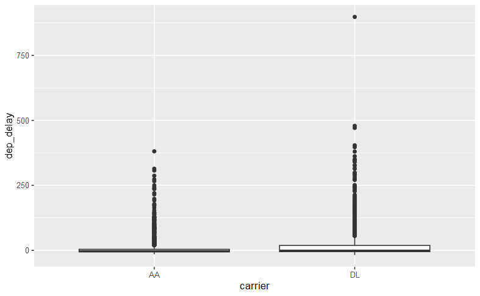

```r
# And more than 150 outliers in each group should be considered extrme

# Check for normality and outliers with boxplots
ggplot(data=lga.flights) +
  geom_boxplot(data=lga.flights, aes(y=dep_delay, x=carrier))
```

```r
# Check for normality with shapiro-wilk test
lga.flights %>%
  group_by(carrier) %>%
  shapiro_test(dep_delay)
```

| carrier | variable | statistic | p |
| --- | --- | --- | --- |
| AA | dep_delay | 0.4825897 | 1.049122e-51 |
| DL | dep_delay | 0.5109268 | 1.769802e-58 |

```r
# Normality not met

# Check for equality of variance between groups
lga.flights %>%
  levene_test(dep_delay ~ carrier)
```

| df1 | df2 | statistic | p |
| --- | --- | --- | --- |
| 1 | 3226 | 32.64344 | 1.207754e-08 |

```r
# Equality of variance not met

# Do test anyway
t.test(dep_delay ~ carrier, data=lga.flights)
```

```
    Welch Two Sample t-test

data:  dep_delay by carrier
t = -7.0077, df = 3222.2, p-value = 2.937e-12
alternative hypothesis: true difference in means between group AA and group DL is not equal to 0
95 percent confidence interval:
 -15.430399  -8.683549
sample estimates:
mean in group AA mean in group DL
        9.538462        21.595436
```

```r
# Indicates significant difference
```

We have several violations of the assumptions and should not trust the outcome of our Student’s t-test. Why? Because the means come from skewed distributions and likely do not reflect the true middle of either group, and also the difference in variance will mess up our comparisons of standard deviations to determine the 95% confidence interval for true difference in means between groups.

Instead, we should use the Mann-Whitney U test, which tests for differences between the medians of two groups, and uses interquartile ranges to generate a 95% confidence interval for true difference in medians between groups. Because we are using medians and IQRs, we have a test that is more robust to errors that may arise from non-normal distributions or inequality of variances.

The assumptions of a Mann-Whitney U test are that the distribution of data in both groups is similar in shape, that the data are independent (no repeated measures within or between groups), and that there are more than 5 observations in each group. We have enough information to confirm we meet these assumptions from the plots we have already made. Let’s proceed with the test.

```r
# Run Mann-Whitney test
wilcox.test(dep_delay ~ carrier, data=lga.flights)
```

```
    Wilcoxon rank sum test with continuity correction

data:  dep_delay by carrier
W = 994584, p-value < 2.2e-16
alternative hypothesis: true location shift is not equal to 0
```

```r
# Calculate median departure delay for each carrier
lga.flights %>%
  group_by(carrier) %>%
  summarise(median.delay = median(dep_delay))
```

| carrier | median.delay |
| --- | --- |
| AA | -3 |
| DL | -1 |

The text output gives us the Wilcoxon W-statistic (which is why R calls this a Wilcoxon test), which is the lowest sum of ranks neede dto calculate the p-value. It also gives us the p-value, which is calculated with a continuity correction to deal with the non-normal distributions. The p-value here is very small, much lower than the threshold alpha value (0.05) to say with 95% confidence that there is a difference. The results indicate that is a significant difference in median departure delay time for Delta and American Airlines flights out of LaGuardia. We calculated median departure delay per group and found that American gets people out the door a median of 3 minutes earlier than their schedule departure time, but Delta only gets people out the door a median of 1 minute earlier than scheduled. We can report that American flights are significantly less delayed than Delta flights.